# Gabriel’s Bioclim

# *Modelling with Bioclim* ———————————————————————————————————————-

##### Workflow: First, only one species then many species in a loop.

##### Objective is the creation of an area-wide presence/absence map.

##### One species

```r
bioclim_model <- bioclim(predictors, df_list[[1]][c("x", "y")])

prediction <- dismo::predict(object = bioclim_model, x = predictors)
```

##### Plot prediction

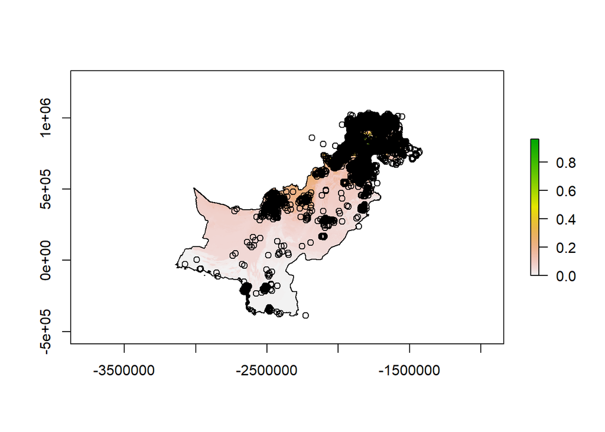

```r
plot(prediction)

plot(pakistan, add=TRUE)

points(df_list[[1]][c("x", "y")])
```

##### Thresholding

```r
threshold_bioclim <- raster::quantile(prediction)[4]

# This is crucial for the results. Here is one Suggestion which uses the third quantile as cut-off value
```

##### Use the threshold for binary presence/absence classification of the prediction

##### Reclassification matrix for reclassify()

```r
classification_matrix <- matrix(c(0, threshold_bioclim, 0,

                                  threshold_bioclim, 1, 1),

                                ncol=3, byrow = TRUE)
```

##### Reclassify

```r
result_presence_absence <- reclassify(prediction, rcl = classification_matrix)
```

##### Plot the distribution of presence and absence data

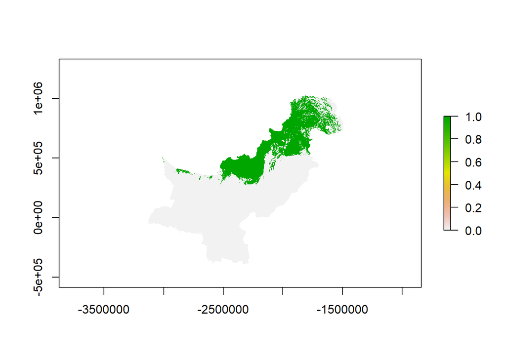

```r
plot(result_presence_absence)
```

##### Now for many species:

```r
presence_absence_maps <- list()

for(i in 1:length(df_list))try({

  cat(i, " ", df_list[[i]]$species[1], "\n")

  bioclim_model      <- bioclim(predictors, df_list[[i]][c("x", "y")])

  prediction         <- dismo::predict(object = bioclim_model, x = predictors)

  threshold_bioclim  <- raster::quantile(prediction)[4]

  classification_matrix <- matrix(c(0, threshold_bioclim, 0, threshold_bioclim, 1, 1),ncol=3, byrow = TRUE)

  result_presence_absence <- reclassify(prediction, rcl = classification_matrix)

  presence_absence_maps[[i]] <- result_presence_absence

  species_name <- df_list[[i]]$species[1]

  names(presence_absence_maps[[i]]) <- species_name # add species name to layer

  writeRaster(presence_absence_maps[[i]], filename = file.path(wd, "output/modelling/bioclim",  species_name), format="GTiff", overwrite=TRUE) # Write out each modeled species as GeoTiff

})
```

```
## 1   distribution_Pakistan_all_test
```

##### Remove empty (null) entries. In this case those with only one record, which failed to be modelled with bioclim().

```r
presence_absence_maps <- presence_absence_maps[!unlist(lapply(presence_absence_maps, is.null))]
```

##### Create RasterStack from list

```r
presence_absence_stack <- stack(presence_absence_maps) # transform list to RasterStack
```

##### Sum over all RasterStack layers to create the final species richness map

```r
richness_map <- stackApply(presence_absence_stack, indices=rep(1,nlayers(presence_absence_stack)), fun = sum, na.rm = TRUE)
```

##### Plot richness_map

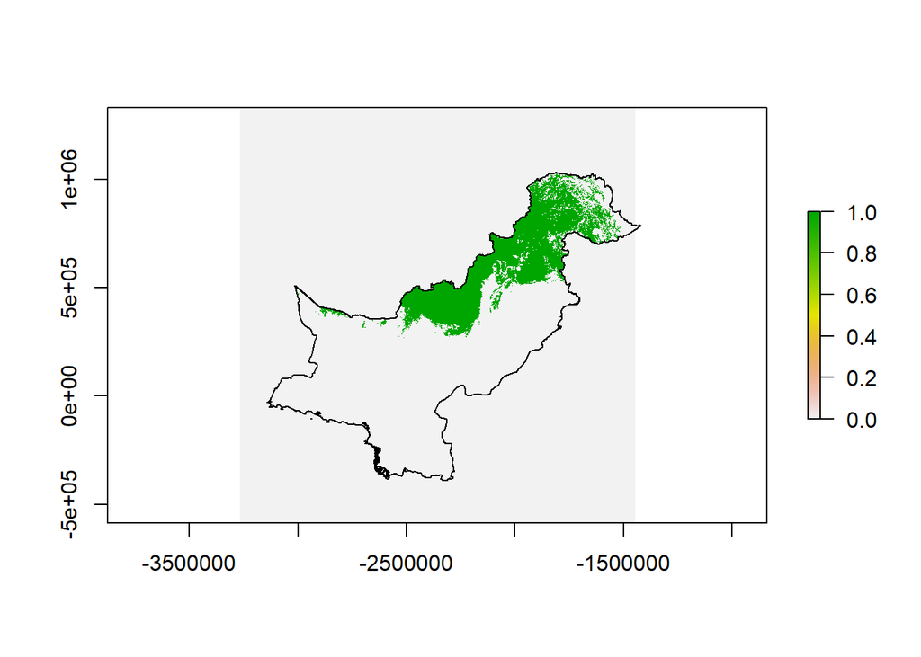

```r
plot(richness_map)

plot(pakistan, add=TRUE)
```

# **Write out** ———————————————————————————————————————-

##### GeoTiff

```r
writeRaster(richness_map, filename = file.path(wd, "bioclim", "richness_map_bioclim"), format="GTiff", overwrite=TRUE)
```

##### JPG

```r
jpeg(filename = file.path(wd, "bioclim", "richness_map_bioclim.jpg"), width = 2000, height = 2000, quality = 99)

plot(richness_map)

plot(pakistan, add=TRUE)

dev.off()
```

##### PDF

```r
pdf(file.path(wd, "bioclim", "richness_map_bioclim.pdf"), width = 10, height = 10)

plot(richness_map)

plot(pakistan, add=TRUE)

dev.off()
```

##### References

Guisan, A., & Zimmermann, N. E. (2000). Predictive habitat distribution models in ecology. Ecological modelling, 135(2-3), 147-186. Hao, T., Elith, J., Guillera‐Arroita, G., & Lahoz‐Monfort, J. J. (2019). A review of evidence about use and performance of species distribution modelling ensembles like BIOMOD. Diversity and Distributions, 25(5), 839-852. Beaumont, L. J., Hughes, L., & Poulsen, M. (2005). Predicting species distributions: use of climatic parameters in BIOCLIM and its impact on predictions of species’ current and future distributions. Ecological modelling, 186(2), 251-270.